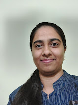

# About Jyoti

**Email ID:** bhogaljyoti1@gmail.com  
**LinkedIn:** jyoti-bhogal  
**Github:** jyoti-bhogal  
**Time Zone:** IST (UTC+5:30 hours)

# **RELEVANT WORK EXPERIENCE**

#### **Incubation Fellow (RSE Asia), OLS (formerly Open Life Science),** January 2026 - Present

- Migrate RSE Asia website to new web framework and theme
- Ongoing maintenance of the RSE Asia website
- Curate a Jobs Board
- Organise and manage RSE Asia meetups
- Create event outcome materials like video recordings, resource sheets, and summary blog posts
- RSE Asia Survey
- **Software Tools:** Hugo, HugoBlox (with Research Group theme), VS Code, git, GitHub, HTML, CSS

#### **2025 Fellow, Institute for Research Software (IRS) (previously the Software Sustainability Institute (SSI)),** January 2025 - Present

- Localising the [IRS surveys](https://www.software.ac.uk/blog/what-do-we-know-about-rses-results-our-international-surveys) to make them suitable for the Asian context
- Conducting research analysis on the anonymised responses to the survey
- Promoting the project and reporting the progress at the biannual [Asia Pacific Advanced Network (APAN)](https://apan.net/) meetings
- Conducting a qualitative and quantitative analysis to develop a community network analysis graph
- **Software Tools:** GitHub, R/Python, VS Code

#### **Research Software Engineering Contributor, Walter and Eliza Hall Institute of Medical Research (WEHI),** November 2024 - Present (Remote, Volunteer)

- Exploring, analysing and visualising cancer genomics data using cBioportal as a free, open-source online database.
- Studying various formats of multiomics data files commonly used in Bioinformatics - raw (.fastq), processed (.bam/.cram), summarised (.vcf) files.
- Cross-team collaborations to prioritise the dependencies.
- **Software Tools:** RStudio, GitHub

#### **Research Software Community Manager, Research Software Alliance (ReSA),** September 2024 - September 2025 (part-time)

- Provide technical support to maintain and update the organisational website
- Manage the task force process, organisation, and internal communications
- Study, maintain, and update the global funding database
- Support stakeholder forums
- Community engagement through social media (LinkedIn, Bluesky, Slack, Mastodon, Mailing list - with engagement rate increasing by 133%, 66%, 63%, 32%, 20% respectively)
- Curate and create monthly newsletters, generate subscription analytics and reports
- **Software Tools:** Hugo framework, VS Code (Terminal), GitHub, git, HTML, CSS

#### **Deloitte Consulting India Pvt. Ltd., Pune -** *Analyst,* April 2022 - September 2024

- *Sanofi Research & Development Data Office (June 2023 - September 2024)*
  - As a Data Governance Consultant for cross-functional Clinical R&D domains, Jyoti laid down standards for a Data Governance Workflow and Policies, and created a centralised Data Catalog in the Informatica Cloud platform Cloud Data Governance and Catalog (CDGC).
  - Developed Conceptual Data models for 6+ transversal R&D business functions.
  - Deeply involved in regular stakeholder communications (business and technical), decision-making, and strategising.
  - **Software Tools:** Informatica Cloud (CDGC), MS Excel, MS Word
- *CognitiveSpark for Clinical (April 2022 - May 2023)*
  - For Structured Content Authoring in the Regulatory domain of Life Sciences, Jyoti developed standardised templates for Clinical Trial Dossier components.
  - Estimated percentage reuse of content from Deloitte’s CognitiveSpark for Clinical (CSC) software asset, and also from within the Clinical Trial Dossier for partially automating the documentation process.
  - **Software Tools:** MS Excel, Workiva, MS Word.

#### **Cytel Statistical Software & Services Pvt. Ltd.,** Pune - *Software Quality Engineer I - Statistician,* September 2020 - March 2022

- Simulated optimal Clinical Trial design to optimise trial cost or statistical power of testing the effectiveness of a drug formula.
- Delivered 6 major software releases which she finished on time and on budget with good statistical power.
- Wrote extensive R program codes to simulate, wrangle, and analyse subject/patient data. Used this output as a benchmark to test the Solara core engine C++ outputs.
- Performed automated and manual testing for software.
- Replicated and presented R Shiny App to determine optimal Sample Size in Clinical Trials, volunteered for weekly Statistics Chapter activities.
- **Software Tools:** R programming language, MS Excel, Postman, Newman.

# **RELEVANT VOLUNTEER COMMUNITY EXPERIENCE**

#### **Research Software Engineering (RSE) Asia Association, Volunteer Co-Lead,** September 2021 - Present

- What is RSE Asia Association?

  **Click here to see more description**

  RSE Asia is a non-profit organisation which works towards building the Research Software Engineer landscape in the Asian region. Jyoti played a crucial role in establishing the RSE Asia Association.
- She organised RSE Asia Community Calls, represented RSE Asia at Asia Pacific Advanced Network (APAN) meetings (APAN58 and APAN59)
- She co-Chaired the 3rd and 4th annual successfully running Research Software Engineering Asia Australia Unconference 2024 (RSEAA24) and the RSAA25 conference.
- She has conducted a 6-month community conversation series on ‘Enabling Open Science Through Research Code’, which created openly available recordings, resource sheets, and summary blog posts of each episode. The average turnout of registrations was around 30% consistently.
- She manages the RSE Asia Association webpage and LinkedIn.

#### **International Council of Research Software Engineering, Co-Observer,** 2022 - Present

- International Council of RSE Associations

  **Click here to see more description**

  The International Council of RSE Associations (*the Council*) provides a formal open forum for established national and multinational RSE associations to talk and coordinate regularly, and thus sustain international collaboration.
- As an observer member of the council, Jyoti provides insights from Asia and fosters connections within the global RSE community.

#### **OLS (formerly Open Life Science) Graduate,** Open Science Project

- What is OLS (formerly Open Life Science)?

  **Click here to see more description**

  OLS is a not-for-profit organisation dedicated to capacity building and diversifying leadership in research worldwide. It runs a mentorship program, now called the Open Seeds program.
- Cohort -4 (OLS-4), September 2021 - January 2022: Project Lead & Community Building Volunteer for ‘Building the Research Software Engineering (RSE) Asia Association.’ Organised RSE Asia Launch Event in collaboration with Hacktoberfest 2021.
- Cohort-5 (OLS-5), February 2022 - July 2022: Project Lead & Community Building Volunteer for ‘Building Pathways for Onboarding to Research Software Engineering (RSE) Asia Association.’, planned & created a working group for the RSE Asia Association.

# **CONFERENCES, WORKSHOPS, TALKS**

### **Conferences that I participated in:**

#### **EARL Tech Conference 2025 (Enterprise Applications of the R Language 2025), Brighton, England | 14-16 October 2025**

- Participated in a hands-on workshop on R for Bayesian Statistics and integrating LLMs in R Shiny applications using the `ellmer` R package.
- Attended various talks and panel discussions on applications of Python and the R programming language in enterprises on various topics like the use of LLMs, data analysis with Python, and marketing research analysis with Python
- Skills: R, R Shiny, Visual Studio Code, GitHub, git, Python

#### **HiddenREF Festival 2025, Birmingham, England | 7-8 October 2025**

- Participated in three sessions on the assessment of non-traditional outputs.
- Presented a lightning talk on ‘Community as Infrastructure: Uncovering the Hidden Impact of Research Software in Research Excellence’.
- Volunteer to help run the conference smoothly by assisting with technical AV.

#### **Open Data Camp 10 (ODC10), Edinburgh, Scotland | 27-28 September 2025**

- Organised a hands-on session on ‘Drawing Parallels: A Unicorn Mandala Art Workshop on Open Data & Collaborations’.
- Contributed to various sessions on Open Data practices, including sessions on Digital Identifiers and National Data Library.

#### **PyCon UK 2025, Manchester, England | 19-22 September 2025**

- Attended various talks and workshops on the Python programming language and its applications in data science, software education, team building, machine learning, LLMs, and software development.
- Attended a one-day hands-on ‘Django Girls Workshop’ to learn Django web application development.
- Presented a lightning talk on ‘Five Common Research Data Management Issues & How to Resolve them: With Python Packaging using ‘Hatch’ from PyPI’.

#### **R Dev Day @ RSECon25, Coventry, England | 8 and 12 September 2025**

- Participated in the dev day to contribute to enhancing documentation of `var.test()` function.
- Contributed to the R `glossary` package to test pre-commit with ‘Write’ access to repository.

#### **RSECon25, Coventry, England | 9-11 September 2025**

- Presented a lightning talk and poster on ‘Enabling Research Software Excellence through RSE Community Conversations: An African and Asian Collaboration’.
- Presented updates from the RSE Asia Association at the RSE Worldwide session.
- Volunteered to help run the conference smoothly.

#### **Open Software Week, London, England | 11-15 August 2025**

- Participated in various hands-on workshops and panel discussions on Open Software practices, including sessions on Introduction to Python, and neuroinformatics software `movement`.
- Participated in the OSW Hackday to explore the concept and open source Python library `skimage` to create skeletonised images from masked images of animals, and derive nodes from the skeletonised image to simplify further analysis.

#### **APAN60, Hong Kong | 27 July - 1 August 2025**

- Signed Memorandum of Understanding (MoU) on behalf of RSE Asia Association with APAN to collaborate on Research Software Engineering and Open Science initiatives in the Asia-Pacific region.
- Presented a talk on ‘Understanding the Personas of Research Software Engineers from Asian Institutes’.
- Held a Warli Art-themed RSE Asia meetup to foster community networking.

#### **Invited Talk, Edinburgh, Scotland | 16 May 2025**

- Presented a talk on my ‘Research Study on the Research Software Engineering (RSEng) Landscape’ at the EPCC, University of Edinburgh.
- [Blog post](https://jyoti-bhogal.github.io/about-me/blog/2025-05-27_epcc_talk/) about the talk.

#### **SuperComputing Asia (SCA) 2025, Online | 10-13 March 2025**

- SuperComouting Asia 2025 is a gathering of the best HPC in Asia.
- Jyoti presented a remote talk on ‘Advancing DEI in Research Software through the Research Software Engineering (RSEng) Asia Association’ in the panel on ‘Diversity and Inclusivity’.

#### **APAN59, Online | 3-7 March 2025**

- Jyoti presented a remote talk at the OSDWG session on the topic ‘Building Bridges: Advancing Research Software Engineering and Open Science in Asia’, and also chaired the session.

#### **PyCon India 2024, Bengaluru, India | 12-15 September 2024**

- PyCon India is an annual conference run by the Python community in India.
- At PyCon India 2024, Jyoti gave a lightning talk on ‘Accelerating India’s Open Science Journey with Python’. She also participated in workshops and a DevDay to learn to contribute to the NumPy open-source Python library.

#### **RSECon24, Online | 3-5 September 2024**

- RSECon24 is organised by the Society of Research Software Engineering (SocRSE), a charitable incorporated organisation based in the UK. It was run in a hybrid mode (London+Remote).
- Jyoti presented a remote Lightning Talk at the RSE Worldwide session to share the status of the RSE Asia Association, participated in the R Development Hackathon to translate 30+ R programming language messages from English to Hindi using Weblate, and attended various other sessions.

#### **APAN58, Online | 26-30 August 2024**

- Asia Pacific Advanced Network is an organisation and also a network that connects the research and education networks of its member countries/economies and other research networks across the world. At APAN58, the 58th bi-annual meeting of APAN, Jyoti remotely presented the journey of the RSE Asia Association so far.

#### **useR 2021, Online | 5-9 July 2021**

- useR! is an annual conference, organised by R community volunteers, and supported by the R Foundation showcases applications and developments of R Software. At useR 2021, Jyoti volunteered as a Zoom Host and participated in various conference sessions on applications of R software, like the R quiz, Research Software Engineering, and many more.

#### **R-Ladies Global, Rotating Curato, Online**

- R-Ladies is a worldwide organisation whose mission is to promote gender diversity in the R community. Jyoti managed the R-Ladies Twitter handle to encourage and maintain communications about the use of R Software language within the R-Ladies global community.

### **Conferences that I attended:**

#### **EARL Tech Conference 2025 (Enterprise Applications of the R Language 2025), Brighton, England | 14-16 October 2025**

- Participated in a hands-on workshop on R for Bayesian Statistics and integrating LLMs in R Shiny applications using the `ellmer` R package.
- Attended various talks and panel discussions on applications of Python and the R programming language in enterprises.

#### **Collaborations Workshop 2025, Stirling, Scotland | 13-15 May 2025**

- Contributed to Green Algorithm’s ‘[GreenMetaData](https://github.com/GreenAlgorithms/MetaGreenData)’ project on hack day and won 1st place amongst 10 teams.
- Wrote a speed blog on the theme ‘futureproofing research software’.
- Contributed to a mini-workshop on ‘How do you ensure your science is seen, used and sustained?’
- Attended keynotes, lightning talks, panel discussions, and social sessions.

#### **Confederation of Open Access Repositories (COAR) Asia Meeting, Conference, New Delhi, India | 17-18 April 2024**

- COAR Asia is a special forum hosted by COAR in which members of the Asian open-access community can share information, meet each other, and build relationships. In the COAR Asia meeting, titled “The promise and practice of open science”, Jyoti represented RSE Asia and discussed the importance of Research Software Engineering to enhance Open Science practices.

#### **Free and Open Source Software (FOSS) United Conference, Pune, India**

- FOSS United is a non-profit foundation that aims at promoting & strengthening the Free and Open Source Software (FOSS) ecosystem in India.
- PuneFOSS 2.0 (24 February 2024): At the FOSS United Pune conference in February 2024, Jyoti attended a day full of interactive sessions on the importance of Free and Open Source Software ecosystem.
- PuneFOSS 2.1 (24 August 2024): Jyoti participated in a hands-on workshop titled ‘Dynamic Secrets: Unleashing the Thor’s Hammer of FOSS’, along with listening to other talks on open source software products like InstructLab and WebAssembly.

#### **PyCon India 2023, Hyderabad, India | 29 Sep - 2 Oct 2023**

- PyCon India is an annual conference run by the Python community in India.
- At PyCon India 2023, Jyoti participated in Python workshops on Data Munging with Python. Furthermore, she gave inputs in an Open Forum discussion on FOSS and Scientific Software Development.

#### **PyData Global 2021, Online | 28 - 30 Oct 2021**

- PyData is a community for developers and users of open-source data tools.
- At PyData Global 2021, Jyoti was selected as a PyData Global Impact Scholar. Amongst many other learnings, she enjoyed a sprint on the usability of the Python package *PyMC.* She continues to be an active member of the PyData community.

# **ACADEMIC PROJECTS**

#### **Analysing Correlation between Geographical Regions via Ocean Surface Temperatures -** *Summer Internship, Indian Institute of Science Education and Research, Pune, India*

- Studied geospatial time series data to understand the correlation between Climate patterns at different geographical locations using the Ocean Surface temperature data.

#### **Analysis of Grammatical Facial Expressions**- *Masters Project*

- Developed an ML algorithm to comprehend facial expressions by using Statistical techniques like Principle Component Analysis (PCA), MANOVA, and LDA on UCI Machine Learning Repository data.
- Achieved 80-90% accuracy in classifying facial expressions.

# **OPEN SCIENCE SKILLS**

- Reproducibility
- FAIR Principles
- Research Data Management

# **CERTIFICATES**

- [Community Engagement Fundamentals Certified - CSCCE](https://api.badgr.io/public/assertions/SHsdenPsRfCIphr4pvso3A?identity__email=bhogaljyoti1%40gmail.com)
- [AWS Certified Cloud Practitioner](https://www.credly.com/badges/2507ea14-96f2-41be-a35e-ba86f2741e57/linked_in?t=rokyrk)
- [AWS Machine Learning Foundation Course](https://confirm.udacity.com/7YXAHKKY)
- Graduate Aptitude Test in Engineering (Statistics) 2020 - All India Rank 48
- Qualified Core Technical 3 – Probability and Mathematical Statistics (CS1-Actuarial Statistics) Level by Institute of Actuaries of India
- Qualified Actuarial Common Entrance Test (ACET) by Institute of Actuaries of India

# **AWARDS**

- [2025 Fellowship of the Institute for Research Software (IRS) (previously the Software Sustainability Institute (SSI))](https://www.software.ac.uk/fellowship-programme/jyoti-bhogal)
- Pfizer Scholarship for Masters
- Meritorious Student Scholarship (based on B.Sc. University Ranking), Savitribai Phule Pune University
- INSPIRE (SHE) Scholarship, DST, Government of India
- Prizes in various Project, Poster, and Quiz competitions

# **TECHNICAL SKILLS**

- R (ggplot2, plotly, stringr, forecast, ts, survival)
- Python (pandas, NumPy, matplotlib, scikit-learn)
- SQL (Basic)
- Hugo
- Jupyter Notebook
- Github
- Bitbucket, Jira, Confluence
- MS Office
- Google Suite

# **LANGUAGES**

English, Hindi, German (Certificate Course)

# **REFERENCES**

1. Yo Yehudi, Executive Director, OLS
2. Malvika Sharan, Director of Strategy and Partnership, OLS
3. Rowland Mosbergen, RCP Strategic Engagement and Planning Manager, Walter and Eliza Hall Institute of Medical Research
4. Anelda van der Walt, Director & Trainer, Talarify

# **EDUCATION**

**Savitribai Phule Pune University (SPPU),** Pune, India - *M.Sc.(Statistics) |* July 2018 - June 2020| CGPA: 9.25/10 | University Rank: 3

**Savitribai Phule Pune University (SPPU),** Pune, India - *B.Sc.(Statistics) |* July 2014 - June 2018 | Percentage: 96.83% | University Rank: 3

**Maharashtra State Board of Secondary & Higher Secondary Education,** Pune, India - *12th Grade |* July 2012 - June 2014 | Percentage: 86.46%

**Central Board of Secondary Education,** New Delhi, India - *10th Grade |* July 2011 - June 2012 | Percentage: 95.00% | GPA: 10/10